# theOtherVictims

Steve Dutky

10/3/2019

# [**All Datasets, files, and images**](https://github.com/sdutky/mcData110/tree/master/otherVictims)

> sdutkyData110Project1TheOtherVictims.Rmd should run in your environment

’’

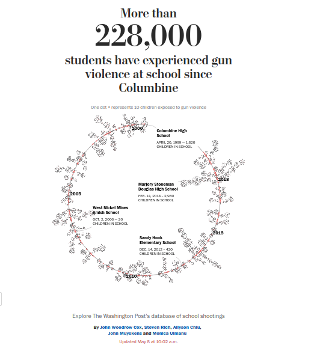

[The Washington Post School Shootings](https://www.washingtonpost.com/graphics/2018/local/school-shootings-database/)

> School shootings are horrific events. By 2018 the Post counted 144 children, teachers and others killed in school assaults and 302 physically injured. All present, however, suffer trauma. Using school enrollment, the Post tallied 228,000 children at 234 school incidents.

## What of the other victims?

> Fortunately, school shootings are rare events. Many children, however, live in proximity to homicidal violence. This is rarely newsworthy.

## Summation

> Combining these datasets discloses, over a period of ten years, nearly two million students enrolled in schools in which a homicide was reported within a mean distance of 142 meters. These schools reported a mean rate of 89% free and reduced price lunches. This indicates that a large majority of these students lived in economically precarious households.

> How close in time and space must a child be near to a homicide to become traumatized? However one answers this, I believe that the data here indicate that the potential trauma suffered by the students enrolled at the sites of school shootings might be eclipsed by the nation wide toll of routine violence.

```r
# load libraries
library(tidyverse)
library(geosphere)
library(lubridate)
```

## Parameters:

```r
param<-list()
param$halfBoxDistance<-174 # meters to sides of bounding box enclosing homicide. Used to find schools inside box
param$homicideUrl="https://github.com/sdutky/mcData110/raw/master/otherVictims/homicide-data.csv"
param$schoolCoordUrl="https://github.com/sdutky/mcData110/raw/master/otherVictims/public-school-locations-2017-18.csv"
param$schoolNcesUrl="https://github.com/sdutky/mcData110/raw/master/otherVictims/nces.csv"
param$schoolNcesGeocodingsUrl="https://github.com/sdutky/mcData110/raw/master/otherVictims/ncesGeocodings.csv"
param$stateBboxUrl="https://gist.githubusercontent.com/a8dx/2340f9527af64f8ef8439366de981168/raw/81d876daea10eab5c2675811c39bcd18a79a9212/US_State_Bounding_Boxes.csv"
```

## load, view, clean, & prep homicide dataset

```r
homicide<-read_csv(param$homicideUrl)
homicide$victim_age<-as.numeric(homicide$victim_age)
#str(homicide)
#summary(homicide)

# drop rows where either lat or lon is NA
homicide<-homicide %>%
  drop_na(lat,lon)

summary(homicide)
```

```
##      uid            reported_date       victim_last
##  Length:52119       Min.   : 20070101   Length:52119
##  Class :character   1st Qu.: 20100318   Class :character
##  Mode  :character   Median : 20121216   Mode  :character
##                     Mean   : 20130905
##                     3rd Qu.: 20150910
##                     Max.   :201511105
##
##  victim_first       victim_race          victim_age     victim_sex
##  Length:52119       Length:52119       Min.   :  0.0   Length:52119
##  Class :character   Class :character   1st Qu.: 22.0   Class :character
##  Mode  :character   Mode  :character   Median : 28.0   Mode  :character
##                                        Mean   : 31.8
##                                        3rd Qu.: 40.0
##                                        Max.   :102.0
##                                        NA's   :2997
##      city              state                lat             lon
##  Length:52119       Length:52119       Min.   :25.73   Min.   :-122.51
##  Class :character   Class :character   1st Qu.:33.77   1st Qu.: -96.00
##  Mode  :character   Mode  :character   Median :38.52   Median : -87.71
##                                        Mean   :37.03   Mean   : -91.47
##                                        3rd Qu.:40.03   3rd Qu.: -81.76
##                                        Max.   :45.05   Max.   : -71.01
##
##  disposition
##  Length:52119
##  Class :character
##  Mode  :character
##
##
##
##
```

```r
#fix error
a<-seq_along(homicide$state)[homicide$state=="wI"]
homicide$state[a]="WI"
print(sort(unique(homicide$state)))
```

```
##  [1] "AL" "AZ" "CA" "CO" "DC" "FL" "GA" "IL" "IN" "KY" "LA" "MA" "MD" "MI"
## [15] "MN" "MO" "NC" "NE" "NM" "NV" "NY" "OH" "OK" "PA" "TN" "TX" "VA" "WI"
```

## filter homicide rows where lat,lon lie outside of the bounding boxes of their respective states

```r
bb<-read_csv(param$stateBboxUrl)
names(bb)[3]<-"state"
bb<-bb[,c("state","xmin","xmax","ymin","ymax")]
hDropped<-nrow(homicide) # get snapshot before
homicide<- homicide %>%
  inner_join(bb,by="state")
homicide<- homicide %>%
  filter(!(lat<=xmax & lat>=xmin & lon<=ymax & lon>=ymin))
hDropped<-hDropped-nrow(homicide) # and after to compare to before
#  All pass filter: no drops

# drop xmin,xmax,ymin,ymax:
homicide<-homicide %>% select(-c(xmin,xmax,ymin,ymax))
```

## 0 homicides outside of state borders dropped

## Identify all schools located within threshold distance of a homicide

```r
bBox<-function(lat,lon,threshold=param$halfBoxDistance) {
  # return list of mid-point lats & lons of bounding box

  # determine the meter distance of 1 degree at location
  dLon<-function(lon,lat) distGeo(c(lon,lat),c(lon+1,lat))
  dLat<-function(lon,lat) distGeo(c(lon,lat),c(lon,lat+1))

  dlon<-mapply(dLon, lon, lat)
  dlat<-mapply(dLat, lon, lat)

  eastSide<-lon+threshold/dlon
  westSide<-lon-threshold/dlon
  northSide<-lat+threshold/dlat
  southSide<-lat-threshold/dlat
  return(tibble(eastSide=eastSide,westSide=westSide,
                southSide=southSide,northSide=northSide))
}
```

## generate the bonding boxes enclosing each homicide and bind it to the homicide tibble

```r
boxes<-bBox(homicide$lat,homicide$lon)
homicide<-cbind(homicide,boxes)
```

## fetch and clean the NCESS dataset of all schools

```r
allSchools<-read_csv(param$schoolNcesUrl)
summary(allSchools) # pre-cleaning
```

```
##  NCES School ID      State School ID    NCES District ID
##  Min.   :1.000e+10   Length:77862       Min.   : 100005
##  1st Qu.:1.202e+11   Class :character   1st Qu.:1201500
##  Median :2.681e+11   Mode  :character   Median :2680620
##  Mean   :2.724e+11                      Mean   :2723611
##  3rd Qu.:4.013e+11                      3rd Qu.:4012615
##  Max.   :5.517e+11                      Max.   :5517220
##
##  State District ID   Low Grade*        High Grade*
##  Length:77862       Length:77862       Length:77862
##  Class :character   Class :character   Class :character
##  Mode  :character   Mode  :character   Mode  :character
##
##
##
##
##  School Name          District         County Name*
##  Length:77862       Length:77862       Length:77862
##  Class :character   Class :character   Class :character
##  Mode  :character   Mode  :character   Mode  :character
##
##
##
##
##  Street Address         City              State                ZIP
##  Length:77862       Length:77862       Length:77862       Min.   : 1001
##  Class :character   Class :character   Class :character   1st Qu.:32750
##  Mode  :character   Mode  :character   Mode  :character   Median :54986
##                                                           Mean   :54655
##                                                           3rd Qu.:78043
##                                                           Max.   :97635
##
##   ZIP 4-digit       Phone           Locale Code*         Locale*
##  Min.   :   1    Length:77862       Length:77862       Length:77862
##  1st Qu.:1710    Class :character   Class :character   Class :character
##  Median :3206    Mode  :character   Mode  :character   Mode  :character
##  Mean   :3901
##  3rd Qu.:5414
##  Max.   :9999
##  NA's   :23865
```

[output cut: 9 more lines]

```
##  Length:77862         Length:77862       Length:77862
##  Class :character     Class :character   Class :character
##  Mode  :character     Mode  :character   Mode  :character
##
##
##
##
##  Student Teacher Ratio* Free Lunch*        Reduced Lunch*
##  Length:77862           Length:77862       Length:77862
##  Class :character       Class :character   Class :character
##  Mode  :character       Mode  :character   Mode  :character
##
##
##
##
```

```r
names(allSchools)<-str_to_title(names(allSchools))
names(allSchools)<-gsub("[[:punct:] ]*","",names(allSchools))

allSchools<-allSchools %>%
      mutate(
        City=str_to_title(City),
        FreeLunch=as.numeric(FreeLunch),
        ReducedLunch=as.numeric(ReducedLunch),
        Students=as.numeric(Students),
        Teachers=as.numeric(Teachers),
        StudentTeacherRatio=as.numeric(StudentTeacherRatio),
        SubsidizedLunchFraction=(FreeLunch+ReducedLunch)/Students,
        NcesSchoolId=as.character(NcesSchoolId)
                          ) %>%
     drop_na(Students,Teachers) %>%
     filter(Students<5000) %>% # remove 8 cyber academies
     filter(Teachers<1000) %>% # Florida Virtual School
     filter(Students>=1 & Teachers>=1)
allSchools$SubsidizedLunchFraction[allSchools$SubsidizedLunchFraction>1]<-NA

summary(allSchools)
```

```
##  NcesSchoolId       StateSchoolId      NcesDistrictId
##  Length:70151       Length:70151       Min.   : 100005
##  Class :character   Class :character   1st Qu.:1300840
##  Mode  :character   Mode  :character   Median :2710060
##                                        Mean   :2779878
##                                        3rd Qu.:4021750
##                                        Max.   :5517220
##
##  StateDistrictId      LowGrade          HighGrade
##  Length:70151       Length:70151       Length:70151
##  Class :character   Class :character   Class :character
##  Mode  :character   Mode  :character   Mode  :character
##
##
##
##
##   SchoolName          District          CountyName
##  Length:70151       Length:70151       Length:70151
##  Class :character   Class :character   Class :character
##  Mode  :character   Mode  :character   Mode  :character
##
##
##
##
##  StreetAddress          City              State                Zip
##  Length:70151       Length:70151       Length:70151       Min.   : 1001
##  Class :character   Class :character   Class :character   1st Qu.:32063
##  Mode  :character   Mode  :character   Mode  :character   Median :53959
##                                                           Mean   :53705
##                                                           3rd Qu.:77401
##                                                           Max.   :97635
##
##    Zip4Digit        Phone            LocaleCode           Locale
##  Min.   :   1    Length:70151       Length:70151       Length:70151
##  1st Qu.:1699    Class :character   Class :character   Class :character
##  Median :3176    Mode  :character   Mode  :character   Mode  :character
##  Mean   :3867
##  3rd Qu.:5322
##  Max.   :9999
##  NA's   :20995
```

[output cut: 9 more lines]

```
##  Length:70151       Min.   :   1.0   Min.   :  1.00   Min.   :  0.00
##  Class :character   1st Qu.: 301.0   1st Qu.: 19.08   1st Qu.: 13.50
##  Mode  :character   Median : 477.0   Median : 29.30   Median : 15.70
##                     Mean   : 568.8   Mean   : 34.67   Mean   : 16.56
##                     3rd Qu.: 698.0   3rd Qu.: 42.97   3rd Qu.: 18.60
##                     Max.   :4841.0   Max.   :308.35   Max.   :852.00
##
##    FreeLunch     ReducedLunch     SubsidizedLunchFraction
##  Min.   :   0   Min.   :   0.00   Min.   :0.000
##  1st Qu.:  93   1st Qu.:   8.00   1st Qu.:0.347
##  Median : 201   Median :  25.00   Median :0.560
##  Mean   : 273   Mean   :  36.07   Mean   :0.557
##  3rd Qu.: 373   3rd Qu.:  47.00   3rd Qu.:0.785
##  Max.   :3866   Max.   :2928.00   Max.   :1.000
##  NA's   :7180   NA's   :8612      NA's   :8652
```

## join up allSchools with schoolEncodings by NcesSchoolId to merge geolocations with school details

```r
schoolCoord<-read_csv(param$schoolCoordUrl)
names(schoolCoord)<-str_to_title(names(schoolCoord))

geoSchools<- schoolCoord[,c("Ncessch","Lat","Lon")] %>%
      inner_join(allSchools,by=c("Ncessch"="NcesSchoolId"  ))
```

## look at the distribution of homicides by city and the distribution of schools in cities with homicides

```r
homicideCityCount<-homicide %>%
  group_by(city) %>%
  summarise(homicides=n())

schoolsCityCount<- allSchools %>%
      group_by(City) %>%
      summarise(schools=n())

homicidesJoinedSchoolsByCity<-inner_join(homicideCityCount,schoolsCityCount,by=c("city" ="City"))

print(homicidesJoinedSchoolsByCity,n=300)
```

```
## # A tibble: 50 x 3
##    city           homicides schools
##    <chr>              <int>   <int>
##  1 Albuquerque          375     174
##  2 Atlanta              973     133
##  3 Baltimore           2827     287
##  4 Baton Rouge          424      97
##  5 Birmingham           799      60
##  6 Boston               612      17
##  7 Buffalo              520      94
##  8 Charlotte            687     173
##  9 Chicago             5535     547
## 10 Cincinnati           694     152
## 11 Columbus            1079     291
## 12 Dallas              1567     373
```

[output cut: 38 more lines]

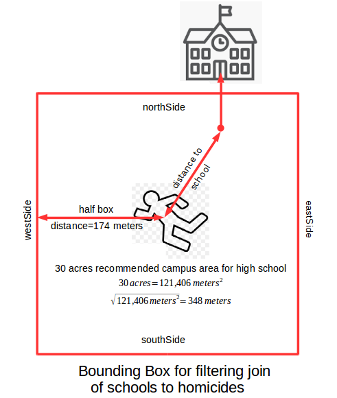

```r
getMatchingSchoolsByCity<-function(cityArg,tblHomicides,tblGeoSchools) {
  as_tibble( tblHomicides %>%
    filter(city==cityArg) %>%
    mutate(dummy=TRUE) %>%
    inner_join(tblGeoSchools %>%
                 filter(City==cityArg) %>%
                 mutate(dummy=TRUE)) %>%
    filter(Lat>southSide,Lat<northSide,Lon>westSide,Lon<eastSide) %>%
    select(-dummy,-city,-state)
  )
}
```

## Collect the schools that fit into the bounding box of each homicide

```r
schoolsNearHomicides<-tibble()
for (city in homicideCityCount$city) {
  schoolsNearHomicides<-rbind(schoolsNearHomicides,getMatchingSchoolsByCity(city,homicide,geoSchools))
}
print(
  paste(
    nrow(schoolsNearHomicides),
    "homicides occuring within",
    param$halfBoxDistance,
    "meters of a school traumatizing",
    sum(schoolsNearHomicides$Students),
    "students")
)
```

```
## [1] "4212 homicides occuring within 174 meters of a school traumatizing 1969084 students"
```

## Calculate distance to school, arrange by date, insert cummulative sums of homicides and students affected

```r
schoolsNearHomicides <- schoolsNearHomicides %>%
  arrange(reported_date)

schoolsNearHomicides$cumHomicides<-cumsum(rep(1,nrow(schoolsNearHomicides)))
schoolsNearHomicides$cumTrauma<-cumsum(schoolsNearHomicides$Students)

f<-function(lat,lon,Lat,Lon) distGeo(c(lon,lat),c(Lon,Lat))

schoolsNearHomicides$distance<-mapply(f,schoolsNearHomicides$lat,schoolsNearHomicides$lon,schoolsNearHomicides$Lat,schoolsNearHomicides$Lon)
```

## Partition allSchools into those not near a homicide

```r
schoolsNotNearHomicides<-allSchools %>%
      anti_join(schoolsNearHomicides,
                by=c("NcesSchoolId"="Ncessch"))
```

## **Between 2007-01-01 and 2017-12-29, 1,969,084 students exposed to 4212 homicides occuring within a mean of 142 meters of a school.**

```r
print.data.frame( schoolsNearHomicides %>%
  group_by(City) %>%
  summarise(exposure=sum(Students),homicides=n()) %>%
  arrange(desc(exposure)) %>%
  mutate(rate=round(exposure/homicides)) %>%
  mutate(exposure=format(exposure,big.mark = ",",scientific = FALSE)),
  width=120)
```

```
##             City exposure homicides rate
## 1        Chicago  432,727       942  459
## 2   Philadelphia  360,567       607  594
## 3      Baltimore  185,097       455  407
## 4     Washington  143,185       396  362
## 5        Houston  100,499       159  632
## 6      Milwaukee   61,449       149  412
## 7    New Orleans   56,894       111  513
## 8        Detroit   51,384       124  414
## 9         Dallas   49,321        97  508
## 10         Miami   43,413        98  443
## 11      New York   39,448        84  470
## 12       Memphis   37,426        85  440
## 13     Las Vegas   36,468        51  715
## 14    Cincinnati   31,166        56  557
```

[output cut: 24 more lines]

## **Plots**

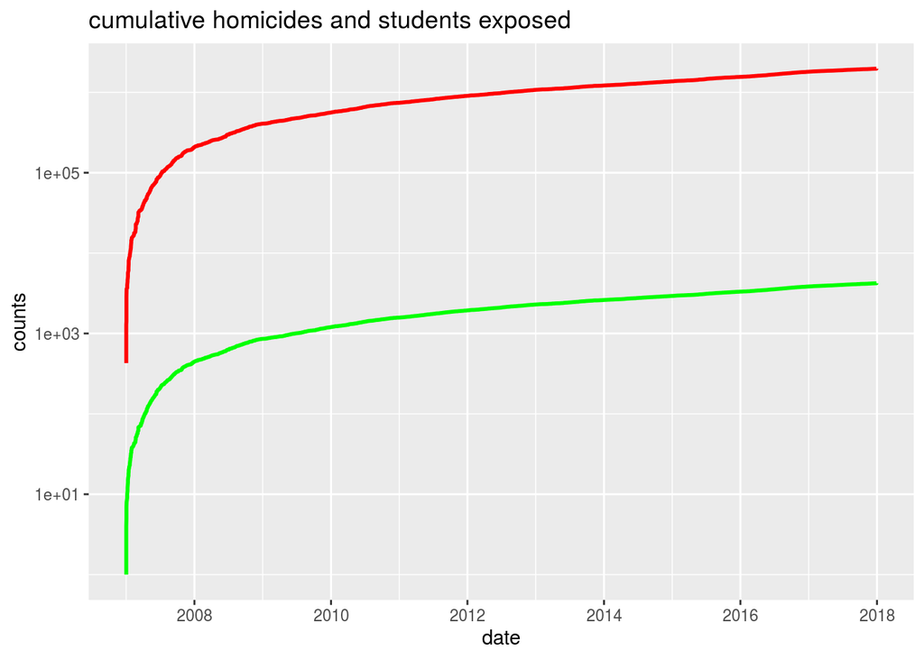

```r
g<-ggplot(schoolsNearHomicides, aes(x=ymd(reported_date))) +                    # basic graphical object
  labs(title="cumulative homicides and students exposed")+
  #scale_x_continuous(name="date")+
  scale_y_continuous(name="counts", trans="log10")+
   xlab("date")+
  #ylab("count")+
  geom_line(aes(y=(cumTrauma)), colour="red",size=1) +  # first layer
  geom_line(aes(y=(cumHomicides)), colour="green",size=1)+  # second layer
  scale_colour_manual("",
                      labels = c("cT", "cH"),
                      values = c("red", "green"))
  #scale_color_discrete(name = "incidents", labels = c("cumHomicides", "cumTrauma"))
g
```

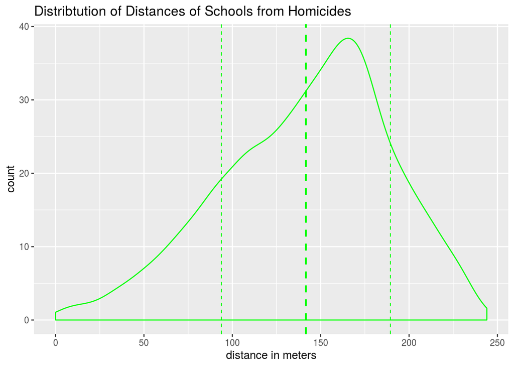

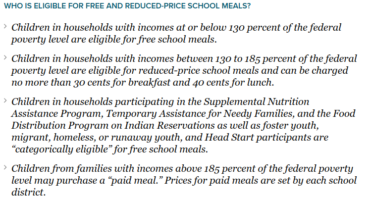

https://frac.org/school-meal-eligibility-reimbursements

```r
title="Distribtution of Distances of Schools from Homicides"

cols=c("Not Near Homicides"="#FF0000","Near Homicides"="#00FF00")
a<-ggplot()+
  labs(title=title,x="distance in meters",
      y="count")+
geom_density(data=schoolsNearHomicides, aes(x=distance,y=..count..),color='green',show.legend=TRUE) +
  geom_vline(data=schoolsNearHomicides,aes(xintercept = mean(distance,na.rm = TRUE)),
             linetype = "dashed",color='green', size = 0.8)+
  geom_vline(data=schoolsNearHomicides,aes(xintercept = mean(distance,na.rm = TRUE)+sd(distance,na.rm = TRUE)),
             linetype = "dashed",color='green', size = 0.4)+
  geom_vline(data=schoolsNearHomicides,aes(xintercept = mean(distance,na.rm = TRUE)-sd(distance,na.rm = TRUE)),
             linetype = "dashed",color='green', size = 0.4)
a
```

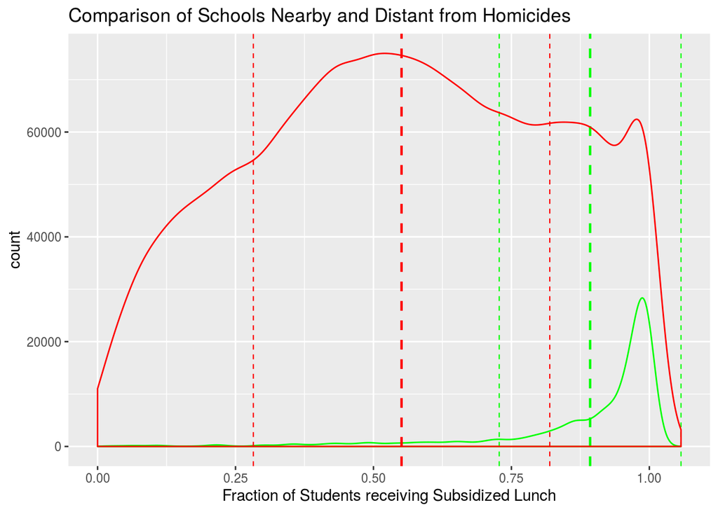

```r
title="Comparison of Schools Nearby and Distant from Homicides"

cols=c("Not Near Homicides"="#FF0000","Near Homicides"="#00FF00")
a<-ggplot()+
  labs(title=title,x="Fraction of Students receiving Subsidized Lunch",
      y="count")+
  scale_colour_manual(name="Schools",values=cols)+
  scale_fill_manual(name="Schools",values=cols) +
geom_density(data=schoolsNearHomicides, aes(x=SubsidizedLunchFraction,y=..count..),color='green',show.legend=TRUE) +
  geom_vline(data=schoolsNearHomicides,aes(xintercept = mean(SubsidizedLunchFraction,na.rm = TRUE)),
             linetype = "dashed",color='green', size = 0.8)+
  geom_vline(data=schoolsNearHomicides,aes(xintercept = mean(SubsidizedLunchFraction,na.rm = TRUE)+sd(SubsidizedLunchFraction,na.rm = TRUE)),
             linetype = "dashed",color='green', size = 0.4)+
  geom_vline(data=schoolsNearHomicides,aes(xintercept = mean(SubsidizedLunchFraction,na.rm = TRUE)-sd(SubsidizedLunchFraction,na.rm = TRUE)),
             linetype = "dashed",color='green', size = 0.4)+
geom_density(data=schoolsNotNearHomicides, aes(x=SubsidizedLunchFraction,y=..count..), color='red',show.legend=TRUE)+
  geom_vline(data=schoolsNotNearHomicides,aes(xintercept = mean(SubsidizedLunchFraction,na.rm = TRUE)),
             linetype = "dashed",color='red', size = 0.8)+
  geom_vline(data=schoolsNotNearHomicides,aes(xintercept = mean(SubsidizedLunchFraction,na.rm = TRUE)+sd(SubsidizedLunchFraction,na.rm = TRUE)),
             linetype = "dashed",color='red', size = 0.4)+
  geom_vline(data=schoolsNotNearHomicides,aes(xintercept = mean(SubsidizedLunchFraction,na.rm = TRUE)-sd(SubsidizedLunchFraction,na.rm = TRUE)),
             linetype = "dashed",color='red', size = 0.4)
a
```

## **Apply t-test to determine significant difference in means for Subsidized Lunches between schools nearby and distant from homicides.**

```r
t.test(schoolsNearHomicides$SubsidizedLunchFraction,
       schoolsNotNearHomicides$SubsidizedLunchFraction)
```

```
##
##  Welch Two Sample t-test
##
## data:  schoolsNearHomicides$SubsidizedLunchFraction and schoolsNotNearHomicides$SubsidizedLunchFraction
## t = 103, df = 3478.9, p-value < 2.2e-16
## alternative hypothesis: true difference in means is not equal to 0
## 95 percent confidence interval:
##  0.3352634 0.3482748
## sample estimates:
## mean of x mean of y
## 0.8926826 0.5509135
```

[output not shown]